# Final Assignment :: Shiny App

March 31, 2019

## Purpose and Details

The assignment was built as part of a deliverable for the course Developing Data Products as part of the Coursera Data Science Specialization.This peer assessed assignment has two parts.

- A. I need to create a Shiny application and deploy it on Rstudio's servers.
- B. Second, I shall use Rstudio Presenter to prepare a reproducible pitch presentation about the application.

The app developed for the first part of the assignment demo is avalilable at https://parthashazrads.shinyapps.io/TruChoiceCar/

Source code for ui.R and server.R files are available on the GitHub repo @ [https://github.com/parthashazra/Shiny-App-Data-Products—JHU-DSS](https://github.com/parthashazra/Shiny-App-Data-Products---JHU-DSS)

## Application Overview

TruChoiceCar site helps user to select correct car for their upcoming trip based on various parameter.

User need to provide your trip detail like distance, price of gasoline, maximum allowed expenditure for gasoline, etc.

Based on these user feedback, Shiny App calculates internally and recommends cars based on your prefernce criteria ordered by expenditure on gasoline.

The result contains filters selected cars will show in a table on the main content with using the mtcars dataset from [R].

## Sneak peek in mtcars Dataset

```
## [1] "First 10 entries from mtcars dataset"
```

```
##                    mpg cyl  disp  hp drat    wt  qsec vs am gear carb
## Mazda RX4         21.0   6 160.0 110 3.90 2.620 16.46  0  1    4    4
## Mazda RX4 Wag     21.0   6 160.0 110 3.90 2.875 17.02  0  1    4    4
## Datsun 710        22.8   4 108.0  93 3.85 2.320 18.61  1  1    4    1
## Hornet 4 Drive    21.4   6 258.0 110 3.08 3.215 19.44  1  0    3    1
## Hornet Sportabout 18.7   8 360.0 175 3.15 3.440 17.02  0  0    3    2
## Valiant           18.1   6 225.0 105 2.76 3.460 20.22  1  0    3    1
## Duster 360        14.3   8 360.0 245 3.21 3.570 15.84  0  0    3    4
## Merc 240D         24.4   4 146.7  62 3.69 3.190 20.00  1  0    4    2
## Merc 230          22.8   4 140.8  95 3.92 3.150 22.90  1  0    4    2
## Merc 280          19.2   6 167.6 123 3.92 3.440 18.30  1  0    4    4
```

## Basic Data Exploration

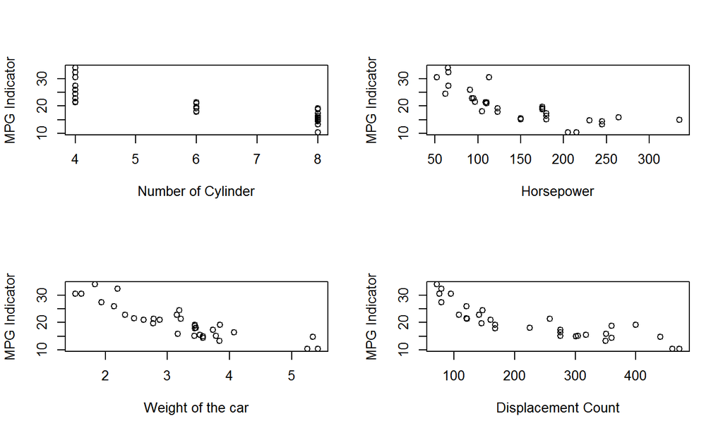

## Basic Data Exploration

For the sake of time for the reviewer, I have restricted data exploration at basic level. We found that MPG is strongly related to number of cyliders, horsepower as well as weight' of the car. Displacement also impacts MPG negatively.

Further analysis can explore more such interesting information if we use lm or regression techniques.

## End of Slide

Thank you for visting my page!!!